# Simulating Data with cellmig

Simo Kitanovski (simo.kitanovski@uni-due.de)

15 May 2026

# Contents

```r
library(cellmig)
library(ggplot2)
library(ggforce)
library(patchwork)
library(rstan)

# Set a clean theme for all plots
ggplot2::theme_set(new = theme_bw(base_size = 10))
```

# 1 Introduction

Why simulate data? Simulation is a powerful tool for:

1. **Validating the model:** Ensuring `cellmig` can recover known truth f rom synthetic data.
2. **Experimental Design:** Performing power analysis to determine how many replicates or cells you need.
3. **Understanding Variability:** Exploring how biological and technical noise affect your results.

This vignette demonstrates two simulation modes in `cellmig`:

- **Partially Generative:** You define the true effect sizes (e.g., drug effects). Useful for validation and power analysis.
- **Fully Generative:** All parameters are drawn from prior distributions. Useful for checking if your priors produce realistic data.

# 2 Partially Generative Simulation

In this mode, you specify the “ground truth” (e.g., exactly how much a drug slows down cells). The model then adds realistic noise (biological and technical variability) to generate synthetic cell velocities.

## 2.1 Experimental Design

We will simulate an experiment with the following structure:

| Parameter | Value | Description |
| --- | --- | --- |
| **Biological Replicates** | 8 Plates | Independent experimental runs |
| **Technical Replicates** | 5 Wells | Wells per treatment per plate |
| **Cells per Well** | 50 | Number of tracked cells |
| **Treatment Groups** | 7 | Different compounds/doses |
| **True Effects (**$\delta$) | -0.4 to 0.4 | Log-fold changes relative to control |
| **Bio Variability (**$\sigma_{bio}$) | 0.1 | Plate-to-plate variation |
| **Tech Variability (**$\sigma_{tech}$) | 0.05 | Well-to-well variation |

## 2.2 Model Parameters

### 2.2.1 Plate Effects ($\alpha_p$)

Plates often have batch effects (e.g., one day cells move faster than another). We simulate this by drawing plate-specific baselines from a normal distribution.

- **Mean:** 0.0 (log-scale velocity)
- **SD:** 0.1 (magnitude of batch effect)

### 2.2.2 Control Treatment (Offset)

To correct for batch effects, one treatment group must serve as a reference (control) across all plates. We designate **Treatment 4** as the control (true effect = 0).

### 2.2.3 Cell Velocity Distribution ($\kappa_w$)

Cell velocities are modeled using a Gamma distribution. The shape parameter $\kappa$ controls the skewness:

- **Higher** $\kappa$: Less variable, more symmetric data.
- **Lower** $\kappa$: More skewed data.
- **Typical value:** $\log(\kappa) \approx 1.5$ ($\kappa \approx 5$).

## 2.3 Generating the Data

We use the `gen_partial()` function. The `control` list specifies all design parameters.

```r
# Set seed for reproducibility
set.seed(1253)

# Generate synthetic data
y_p <- gen_partial(control = list(
  N_biorep = 8,                  # Number of plates
  N_techrep = 5,                 # Wells per treatment per plate
  N_cell = 50,                   # Cells per well
  delta = c(-0.4, -0.2, -0.1, 0, 0.1, 0.2, 0.4), # True treatment effects
  sigma_bio = 0.1,               # Biological variability
  sigma_tech = 0.05,             # Technical variability
  offset = 4,                    # Index of the control treatment
  prior_alpha_p_M = 0,           # Mean plate baseline
  prior_alpha_p_SD = 0.1,        # SD of plate baseline
  prior_kappa_mu_M = 1.5,        # Mean log(shape parameter)
  prior_kappa_mu_SD = 0.1,       # SD of log(shape parameter)
  prior_kappa_sigma_M = 0,       # Fixed sigma for shape
  prior_kappa_sigma_SD = 0.1     # SD of sigma for shape
))
```

## 2.4 Inspecting the Simulated Data

The output `y_p` contains the data frame `y` and the true parameters `par`.

```r
str(y_p$y)
```

```
FALSE 'data.frame': 14000 obs. of  6 variables:
FALSE  $ v       : num  0.566 1.129 0.798 2.149 0.79 ...
FALSE  $ well    : int  1 1 1 1 1 1 1 1 1 1 ...
FALSE  $ plate   : int  1 1 1 1 1 1 1 1 1 1 ...
FALSE  $ group   : int  1 1 1 1 1 1 1 1 1 1 ...
FALSE  $ compound: int  1 1 1 1 1 1 1 1 1 1 ...
FALSE  $ dose    : chr  "X" "X" "X" "X" ...
```

The data frame includes:

- `v`: Simulated cell velocity.
- `well`, `plate`: Hierarchical identifiers.
- `group`: Treatment group ID.
- `compound`, `dose`: Metadata (set to generic values in simulation).

## 2.5 Visualizing Simulated Data

Let’s plot the raw cell velocities. Colors represent plates. If batch effects are present, you might see plate colors clustering at different heights.

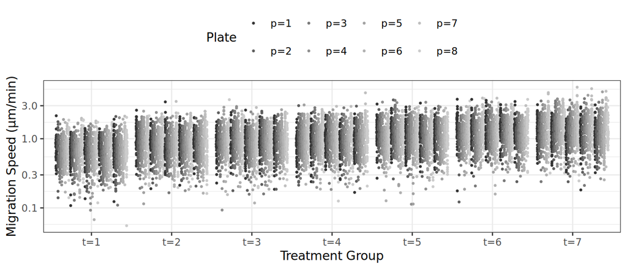

```r
ggplot(data = y_p$y) +
  geom_sina(aes(x = paste0("t=", group), col = paste0("p=", plate),
                y = v, group = well), size = 0.5) +
  xlab("Treatment Group") +
  ylab("Migration Speed (µm/min)") +
  scale_color_grey(name = "Plate") +
  scale_y_log10() +
  theme(legend.position = "top")
```

We can also look at **mean well velocities** to see batch effects more clearly:

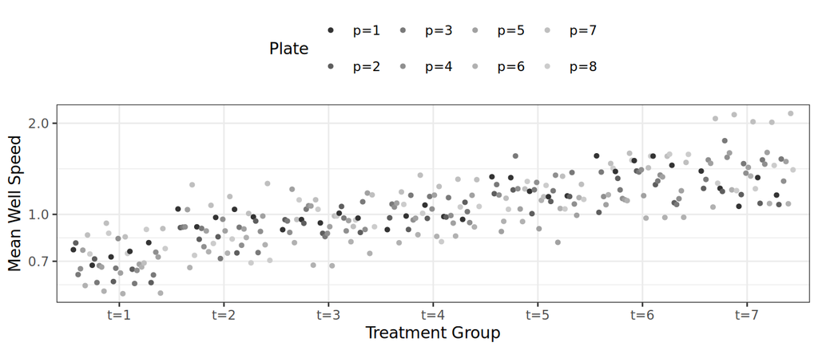

```r
well_means <- aggregate(v ~ well + group + plate, data = y_p$y, FUN = mean)

ggplot(data = well_means) +
  geom_sina(aes(x = paste0("t=", group), col = paste0("p=", plate),
                y = v, group = well), size = 1) +
  xlab("Treatment Group") +
  ylab("Mean Well Speed") +
  scale_color_grey(name = "Plate") +
  scale_y_log10() +
  theme(legend.position = "top")
```

## 2.6 Analyzing Simulated Data

To verify the model works, we analyze the synthetic data just like real experimental data.

**Important:** We must format the data correctly:

1. Convert IDs to characters.
2. Create an `offset` column (1 for control, 0 for others).

```r
sim_data <- y_p$y

# Format columns
sim_data$well <- as.character(sim_data$well)
sim_data$compound <- as.character(sim_data$compound)
sim_data$plate <- as.character(sim_data$plate)

# Define offset (Control = Group 4)
sim_data$offset <- 0
sim_data$offset[sim_data$group == 4] <- 1
```

Now we fit the model:

```r
osd <- cellmig(x = sim_data,
               control = list(mcmc_warmup = 250,
                              mcmc_steps = 800,
                              mcmc_chains = 2,
                              mcmc_cores = 2,
                              mcmc_algorithm = "NUTS",
                              adapt_delta = 0.8,
                              max_treedepth = 10))
```

```
FALSE Warning: There were 1 divergent transitions after warmup. See
FALSE https://mc-stan.org/misc/warnings.html#divergent-transitions-after-warmup
FALSE to find out why this is a problem and how to eliminate them.
```

```
FALSE Warning: Examine the pairs() plot to diagnose sampling problems
```

## 2.7 Validation: Truth vs. Inference

Does `cellmig` recover the true parameters we set? We compare the **posterior estimates** (dots + error bars) against the **true values** (red dots).

### 2.7.1 Plate Effects ($\alpha_p$)

The model should recover the plate-specific baselines.

```
FALSE Warning: `geom_errobarh()` was deprecated in ggplot2 4.0.0.
FALSE ℹ Please use the `orientation` argument of `geom_errorbar()` instead.
FALSE This warning is displayed once every 8 hours.
FALSE Call `lifecycle::last_lifecycle_warnings()` to see where this warning was
FALSE generated.
```

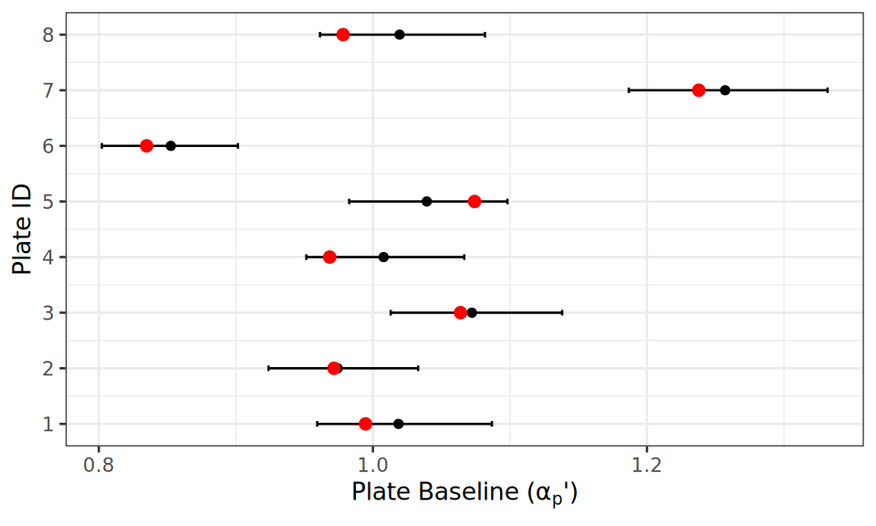

```r
ggplot(data = osd$posteriors$alpha_p) +
  geom_point(aes(y = plate_id, x = exp(mean))) +
  geom_errorbarh(aes(y = plate_id, x = exp(mean), xmin = exp(X2.5.),
                     xmax = exp(X97.5.)), height = 0.1) +
  # Overlay true values in red
  geom_point(data = data.frame(v = exp(y_p$par$alpha_p),
                               plate = osd$posteriors$alpha_p$plate_id),
             aes(y = plate, x = v), col = "red", size = 2) +
  xlab(label = expression("Plate Baseline ("*alpha[p]*"')")) +
  ylab("Plate ID") +
  scale_y_continuous(breaks = osd$posteriors$alpha_p$plate_id)
```

### 2.7.2 Treatment Effects ($\delta_t$)

The model should recover the true log-fold changes we defined in `delta`.

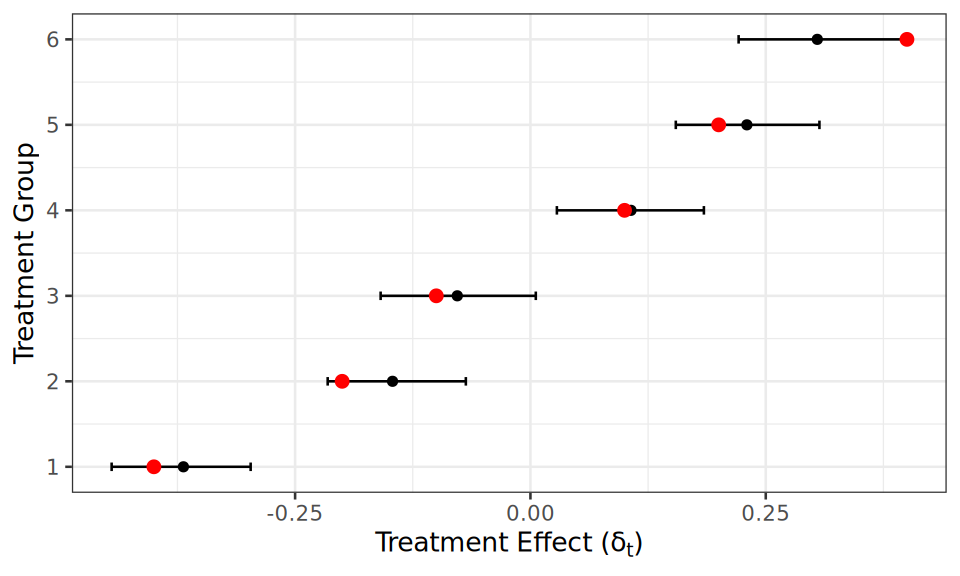

```r
# Note: Group 4 is the control (offset), so it is not estimated
ggplot(data = osd$posteriors$delta_t) +
  geom_point(aes(y = group_id, x = mean)) +
  geom_errorbarh(aes(y = group_id, x = mean, xmin = X2.5., xmax = X97.5.),
                 height = 0.1) +
  # Overlay true values (excluding control)
  geom_point(data = data.frame(delta = c(-0.4, -0.2, -0.1, 0.1, 0.2, 0.4),
                               group_id = 1:6),
             aes(y = group_id, x = delta), col = "red", size = 2) +
  xlab(label = expression("Treatment Effect ("*delta[t]*")")) +
  ylab("Treatment Group") +
  scale_y_continuous(breaks = 1:8)
```

### 2.7.3 Variability Parameters

Check if the estimated biological and technical noise matches the input.

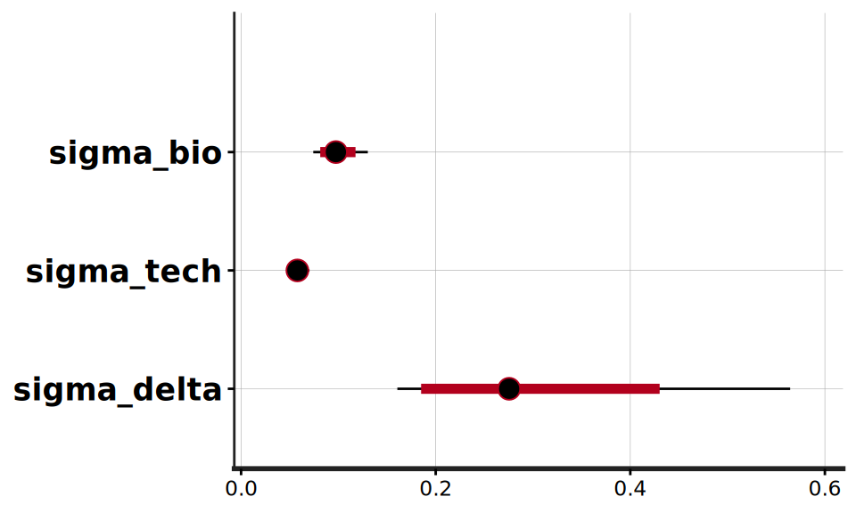

```r
plot(osd$fit, par = c("sigma_bio", "sigma_tech", "sigma_delta"))
```

# 3 Fully Generative Simulation

In this mode, **no parameters are fixed**. Everything (including treatment effects) is drawn from the prior distributions. This generates data from the **prior predictive distribution**.

**Use Case:** Check if your priors produce realistic data before collecting any real samples. If the simulated velocities are biologically impossible (e.g., 1000 µm/min), your priors may need adjustment.

## 3.1 Model Specification

We define priors for all parameters instead of fixed values.

```r
control_full <- list(
  N_biorep = 4,
  N_techrep = 3,
  N_cell = 30,
  N_group = 8,
  # Priors for plate baselines
  prior_alpha_p_M = -0.5,
  prior_alpha_p_SD = 1.0,
  # Priors for Gamma shape
  prior_kappa_mu_M = 1.5,
  prior_kappa_mu_SD = 1.0,
  prior_kappa_sigma_M = 0,
  prior_kappa_sigma_SD = 1.0,
  # Priors for variability
  prior_sigma_bio_M = 0.0,
  prior_sigma_bio_SD = 1.0,
  prior_sigma_tech_M = 0.0,
  prior_sigma_tech_SD = 1.0,
  prior_sigma_delta_M = 0.0,
  prior_sigma_delta_SD = 1.0
)
```

## 3.2 Generate Data

```r
y_f <- gen_full(control = control_full)
```

```
FALSE Chain 1:
FALSE Chain 1:  Elapsed Time: 0 seconds (Warm-up)
FALSE Chain 1:                0.001 seconds (Sampling)
FALSE Chain 1:                0.001 seconds (Total)
FALSE Chain 1:
```

```r
str(y_f)
```

```
FALSE List of 2
FALSE  $ y      :'data.frame':  2880 obs. of  8 variables:
FALSE   ..$ i       : int [1:2880] 1 2 3 4 5 6 7 8 9 10 ...
FALSE   ..$ v       : num [1:2880] 0.267 1.136 0.347 0.98 3.315 ...
FALSE   ..$ well    : chr [1:2880] "1" "1" "1" "1" ...
FALSE   ..$ plate   : chr [1:2880] "1" "1" "1" "1" ...
FALSE   ..$ group   : chr [1:2880] "1" "1" "1" "1" ...
FALSE   ..$ compound: chr [1:2880] "1" "1" "1" "1" ...
FALSE   ..$ dose    : chr [1:2880] "X" "X" "X" "X" ...
FALSE   ..$ trep_id : int [1:2880] 1 1 1 1 1 1 1 1 1 1 ...
FALSE  $ control:List of 19
FALSE   ..$ N_biorep            : num 4
FALSE   ..$ N_techrep           : num 3
FALSE   ..$ N_cell              : num 30
FALSE   ..$ N_group             : num 8
FALSE   ..$ prior_alpha_p_M     : num -0.5
FALSE   ..$ prior_alpha_p_SD    : num 1
FALSE   ..$ prior_kappa_mu_M    : num 1.5
FALSE   ..$ prior_kappa_mu_SD   : num 1
FALSE   ..$ prior_kappa_sigma_M : num 0
FALSE   ..$ prior_kappa_sigma_SD: num 1
FALSE   ..$ prior_sigma_bio_M   : num 0
FALSE   ..$ prior_sigma_bio_SD  : num 1
FALSE   ..$ prior_sigma_tech_M  : num 0
FALSE   ..$ prior_sigma_tech_SD : num 1
FALSE   ..$ prior_sigma_delta_M : num 0
FALSE   ..$ prior_sigma_delta_SD: num 1
FALSE   ..$ offset              : num 1
FALSE   ..$ N_plate             : num 4
FALSE   ..$ N_well_reps         : num 3
```

## 3.3 Comparing Simulation Modes

Do the two simulation modes produce similar ranges of cell velocities?

```
FALSE Warning: Removed 101 rows containing non-finite outside the scale range
FALSE (`stat_density2d()`).
```

```
FALSE Warning: Removed 101 rows containing missing values or values outside the scale range
FALSE (`geom_point()`).
```

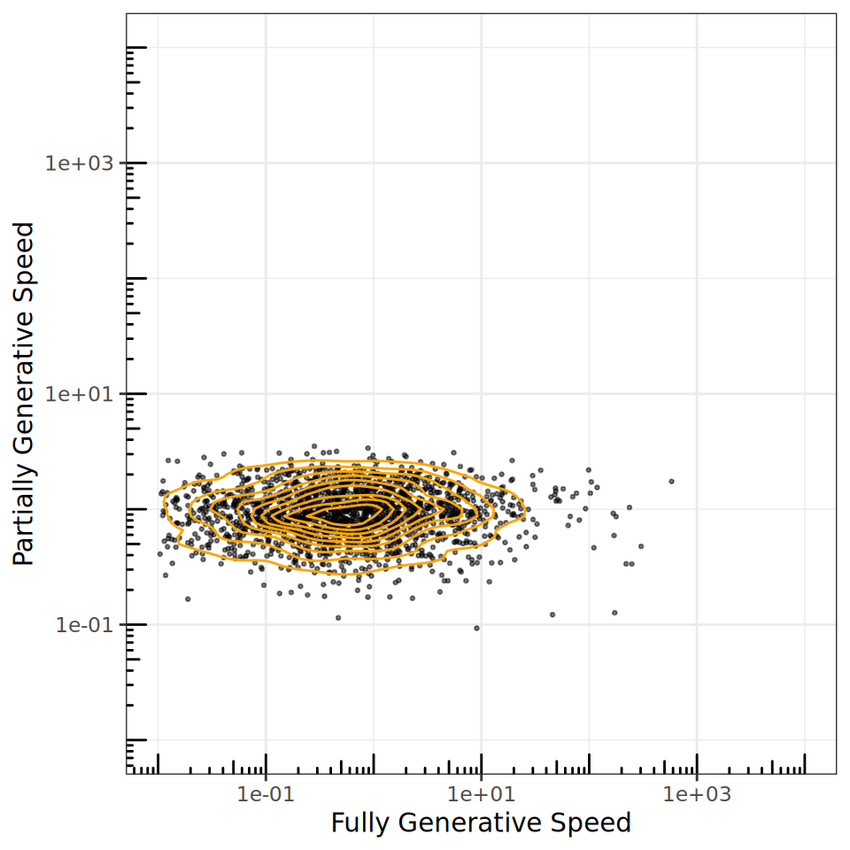

```r
# Compare a subset of velocities
w <- data.frame(v_f = y_f$y$v[1:2000], v_p = y_p$y$v[1:2000])

ggplot(data = w) +
  geom_point(aes(x = v_f, y = v_p), size = 0.5, alpha = 0.5) +
  geom_density_2d(aes(x = v_f, y = v_p), col = "orange") +
  scale_x_log10(name = "Fully Generative Speed", limits = c(0.01, 10^4)) +
  scale_y_log10(name = "Partially Generative Speed", limits = c(0.01, 10^4)) +
  annotation_logticks(base = 10, sides = "lb") +
  theme_bw()
```

# 4 Power Analysis

One of the most practical uses of simulation is **power analysis**. *Question:* How many biological replicates (plates) do I need to detect a specific effect size?

We can answer this by:

1. Simulating many datasets with varying numbers of replicates.
2. Fitting the model to each.
3. Checking how often the model correctly identifies the true effect (True Positive Rate).

**Note:** The code below is computationally intensive (it fits many models). It is set to `eval = FALSE` for this vignette. You can run it locally to perform your own power analysis. **Tip:** Use multiple cores (`mcmc_cores`) to speed this up!

## 4.1 Simulation Loop

```r
# --- Configuration ---
N_bioreps <- c(3, 6, 9)      # Replicate scenarios to test
N_sim <- 10                  # Number of simulations per scenario
true_deltas <- c(-0.3, -0.15, 0, 0.2, 0.4) # Effects to test
offset <- 3                  # Control group index

# Store results
deltas <- vector(mode = "list", length = length(N_bioreps) * N_sim)
i <- 1

for(N_biorep in N_bioreps) {
  for(b in 1:N_sim) {

    # 1. Simulate data
    y_p <- gen_partial(control = list(
      N_biorep = N_biorep,
      N_techrep = 3,
      N_cell = 40,
      delta = true_deltas,
      sigma_bio = 0.1,
      sigma_tech = 0.05,
      offset = offset,
      prior_alpha_p_M = -0.5,
      prior_alpha_p_SD = 0.1,
      prior_kappa_mu_M = 1.5,
      prior_kappa_mu_SD = 0.1,
      prior_kappa_sigma_M = 0,
      prior_kappa_sigma_SD = 0.1
    ))

    # 2. Format data
    sim_data <- y_p$y
    sim_data$well <- as.character(sim_data$well)
    sim_data$compound <- as.character(sim_data$compound)
    sim_data$plate <- as.character(sim_data$plate)
    sim_data$offset <- 0
    sim_data$offset[sim_data$group == offset] <- 1

    # 3. Fit model
    o <- cellmig(x = sim_data,
                 control = list(mcmc_warmup = 300,
                                mcmc_steps = 1000,
                                mcmc_chains = 1,
                                mcmc_cores = 1, # Increase for speed
                                mcmc_algorithm = "NUTS",
                                adapt_delta = 0.8,
                                max_treedepth = 10))

    # 4. Evaluate Performance
    delta <- o$posteriors$delta_t
    delta$b <- b
    delta$N_biorep <- N_biorep
    delta$true_deltas <- true_deltas[-offset]

    # True Positive: HDI excludes 0 AND includes true value
    delta$TP <- (delta$X2.5. <= delta$true_deltas &
                   delta$X97.5. >= delta$true_deltas) &
      !(delta$X2.5. <= 0 & delta$X97.5. >= 0)

    deltas[[i]] <- delta
    i <- i + 1
  }
}

# Combine results
deltas <- do.call(rbind, deltas)
```

## 4.2 Interpreting Results

When you run this analysis, you will typically observe:

- **Large Effects** (e.g., $|\delta| > 0.3$): Detected reliably even with few replicates (High True Positive rate).
- **Small Effects** (e.g., $|\delta| < 0.2$): Require many biological replicates to distinguish from noise.

```r
ggplot(data = aggregate(TP ~ N_biorep + true_deltas, data = deltas, FUN = sum)) +
  geom_point(aes(x = N_biorep, y = TP, col = abs(true_deltas),
                 group = as.factor(true_deltas)), size = 2, alpha = 0.5) +
  geom_line(aes(x = N_biorep, y = TP, col = abs(true_deltas),
                group = as.factor(true_deltas)), alpha = 0.5) +
  ylab("Number of True Positives (TPs)") +
  xlab("Number of Biological Replicates") +
  scale_color_distiller(name = expression("|"*delta[t]*"|"), palette = "Spectral") +
  theme_bw()
```

[output not shown]